# R-Graphics tool: part I

August, 2017

## Plotting points

## plot

### mtcars data analysis:

```
+ mtcars contains (mpg: mile per gallon) and (disp: displacement) ...
```

```r
    attach(mtcars)
    head(mtcars, n = 2)
```

```
##               mpg cyl disp  hp drat    wt  qsec vs am gear carb
## Mazda RX4      21   6  160 110  3.9 2.620 16.46  0  1    4    4
## Mazda RX4 Wag  21   6  160 110  3.9 2.875 17.02  0  1    4    4
```

- `?mtcars`

## plot

### `plot()`

- the relation between two variables can be explored by plot.

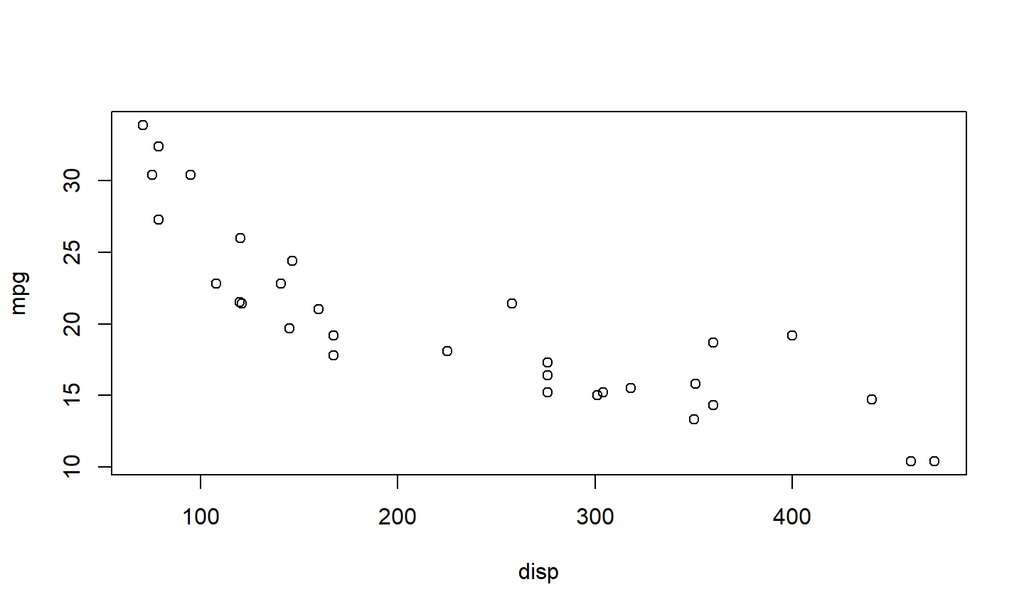

```r
plot(mpg ~ disp, data = mtcars)
```

## plot

```r
plot(mpg ~ disp, data = mtcars)
```

- mtcars is datafame
- `mpg~disp` denotes the relation between `mpg` and `disp` which are the column name of the dataframe.
- In `mpg~disp` a points take the value of y-axis from `mpg` and of x-axis from `disp`.

## plot

### Exercise

- Draw a plot of which y-axis is `hp` (horse power) and x-axis is `disp`.

## plot

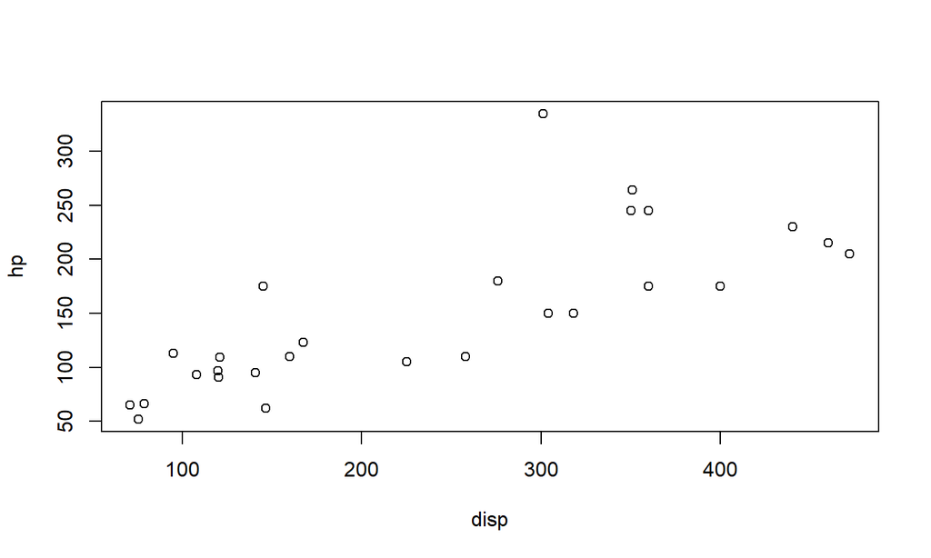

```r
plot(hp ~ disp, data = mtcars)
```

## plot

### Draw a plot by vectors.

- We can use vectors to draw a plot.

```r
x = rnorm(100)
y = 2+2*x + rnorm(100)
plot(x,y, main = "plot (x-y)")
```

- `rnorm(100)` choose 100 random number for the standard normal distribution.
- The value of point on the y-axis is given by \(y = 2 + 2x + \epsilon\) where \(\epsilon \sim N(0, \sigma^2\).
- `main = "plot (x-y)"` adds the title in the plot.

## plot

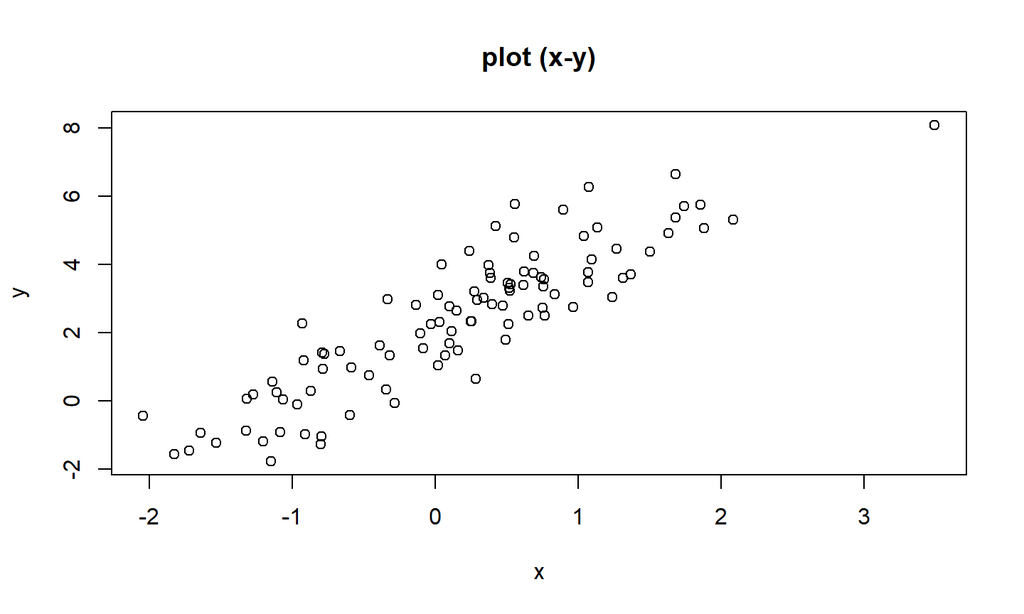

## plot

### Drawing option

- plot function can draw some graphical object between points which are adjacent in vectors (not values).

#### option: the type of the graphical object

- `type = 'p'`: point
- `type = 'l'`: line
- `type = 'b'` : both point and line
- `type = 's'` : step
- By `?plot` you can see more information about options.

## plot

### Drawing option

```r
x = seq(-2,2, length = 10)
y = x^2
plot(x,y, type = 'p', main = "y = x^2")
```

[output not shown]

## plot

### Drawing option

- What is the graph with `type = 'b'`?

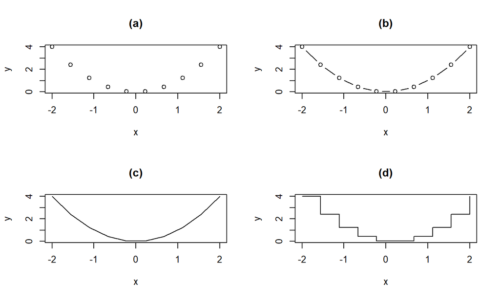

## plot

### Drawing option

- By `lty` option we can set a type of lines connecting the points
- `?par` and chekc the `lty` option.

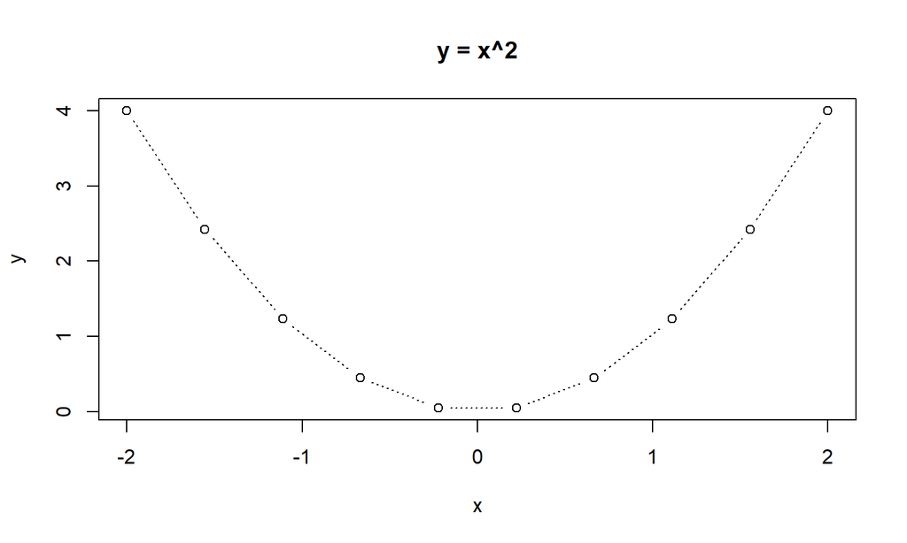

```r
plot(x,y, type = "b", lty = 3, main = "y = x^2")
```

## plot

### Drawing option

- pch (plotting symbol)

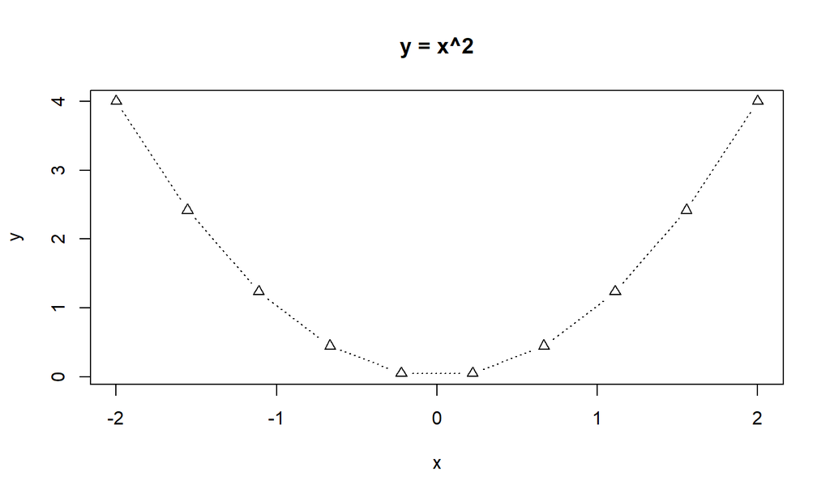

```r
plot(x,y, type = "b", lty = 3, pch = 2, main = "y = x^2")
```

## plot

### Drawing option

- Exercise: explain the result of the following code.

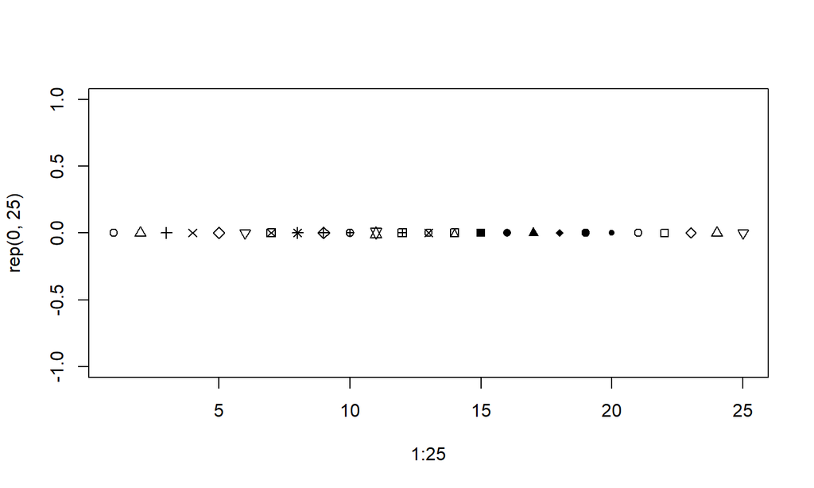

```r
plot(x = 1:25,y = rep(0, 25), pch = 1:25)
```

## plot

### Drawing option

- col (color)

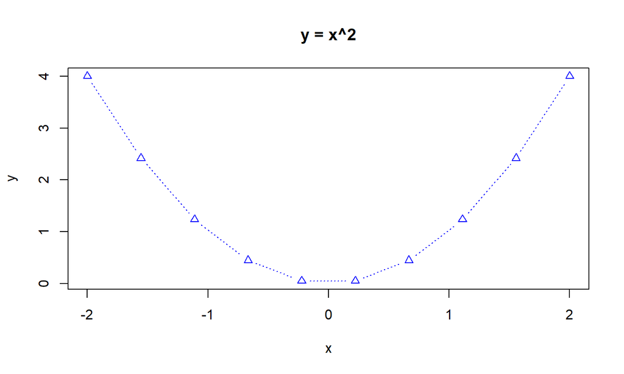

```r
plot(x,y, type = "b", lty = 3, pch = 2,
     col = "blue", main = "y = x^2")
```

## plot

### Drawing option

- The function `colors()` returns the list of the names of available colors

```r
colors()[1:10]
```

```
##  [1] "white"         "aliceblue"     "antiquewhite"  "antiquewhite1"
##  [5] "antiquewhite2" "antiquewhite3" "antiquewhite4" "aquamarine"
##  [9] "aquamarine1"   "aquamarine2"
```

## plot

### Axis option

- label on axis: `xlab`, `ylab`

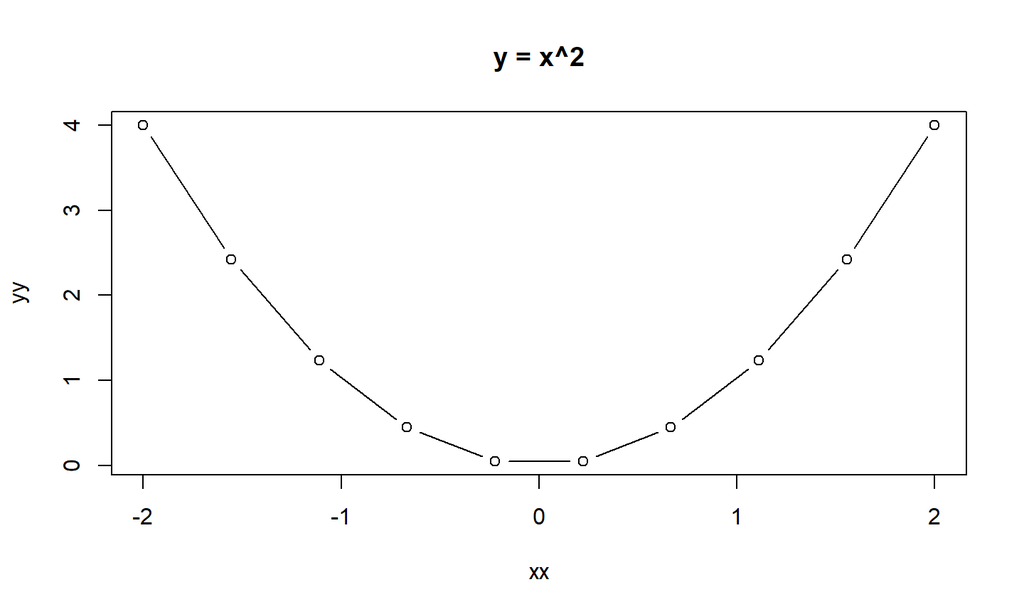

```r
plot(x,y, type = "b", xlab = "xx", ylab = "yy", main = "y = x^2")
```

## plot

### Drawing multiple plots

- Using Formula provides a plot with multiple panels.

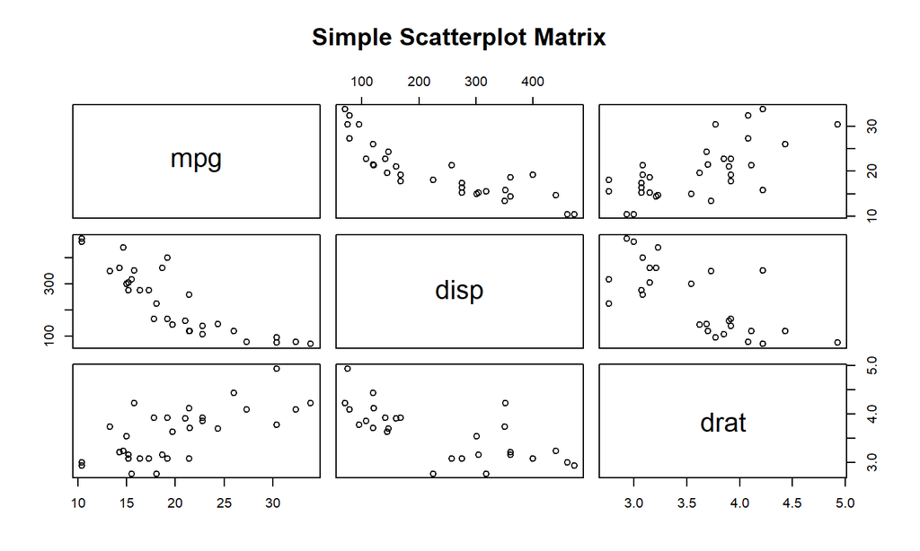

```r
plot(~mpg+disp+drat,data=mtcars,
   main="Simple Scatterplot Matrix")
```

## Add lines and points

## abline

- abline is a function to draw on the existing plot.

### abline() draws

- the line with intercept \(a\) and slope \(b\)
- the horizontal line
- the vertical line

```r
x = rnorm(100)
y = 2+2*x + rnorm(100)
plot(x,y, pch = 20, main = 'scatter plot')
abline(a = 1, b = 2, col = "red")
abline(v = 1, col = "blue")
abline(h = 1, col = "green")
```

## abline

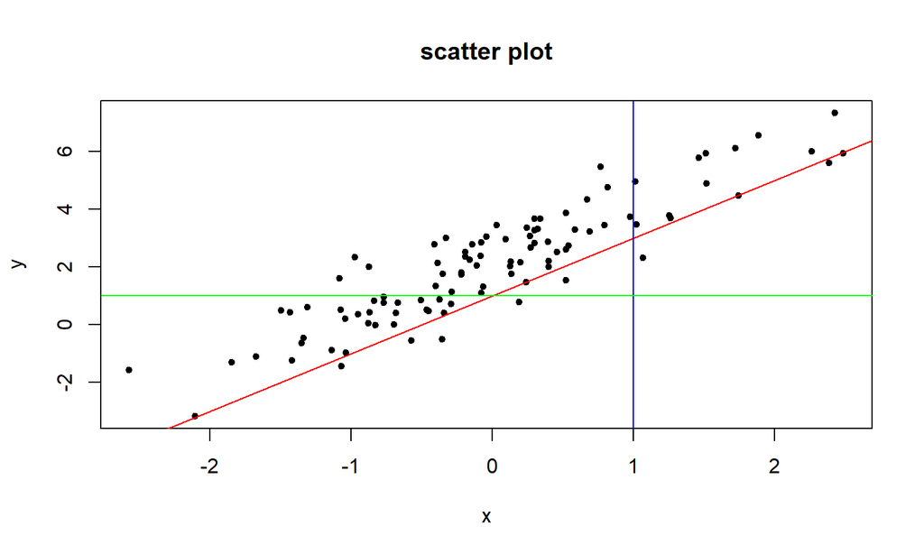

## points

### options

- `type` is same as the option in the `plot()`.
- `lty` is same as the option in the `plot()`

```r
plot(x = 1,y = 1, type = 'n', xlim = c(0,10), ylim = c(0,5),
     xlab = 'time', ylab = '# of visiting')
x = 0:10
set.seed(1)
y = rpois(length(x), lambda = 1)
points(x,y, col = "blue", type = "s")
points(x,y, col = "red", type = "l")
```

[output not shown]

## plot

### range of axis

- options:xlim and ylim. Note that the option requires the vector with length 2.

```r
x = 0:10
set.seed(1)
y = rpois(length(x), lambda = 1)
plot(x,y, type = "b", xlab = "x-variable",
     ylab = "y-variable", main = "y = x^2",
     xlim = c(-1,1), ylim = c(-1,1))
```

[output not shown]